# Exploratory Data Analysis of Prosper Loan Data by Rajesh Nair

The correlation coefficient is 0.050 which suggests that the correlation is not meaningful. The regression line is gradually increasing. The DebtToIncomeRatio is more dispersed for higher values of TradesNeverDelinquent_percentage and the 2 extremes are more wider for higher values of TradesNeverDelinquent_percentage and is narrower for the lower values of TradesNeverDelinquent_percentage. There are more data points for higher values of TradesNeverDelinquent_percentage as compared to the lower values

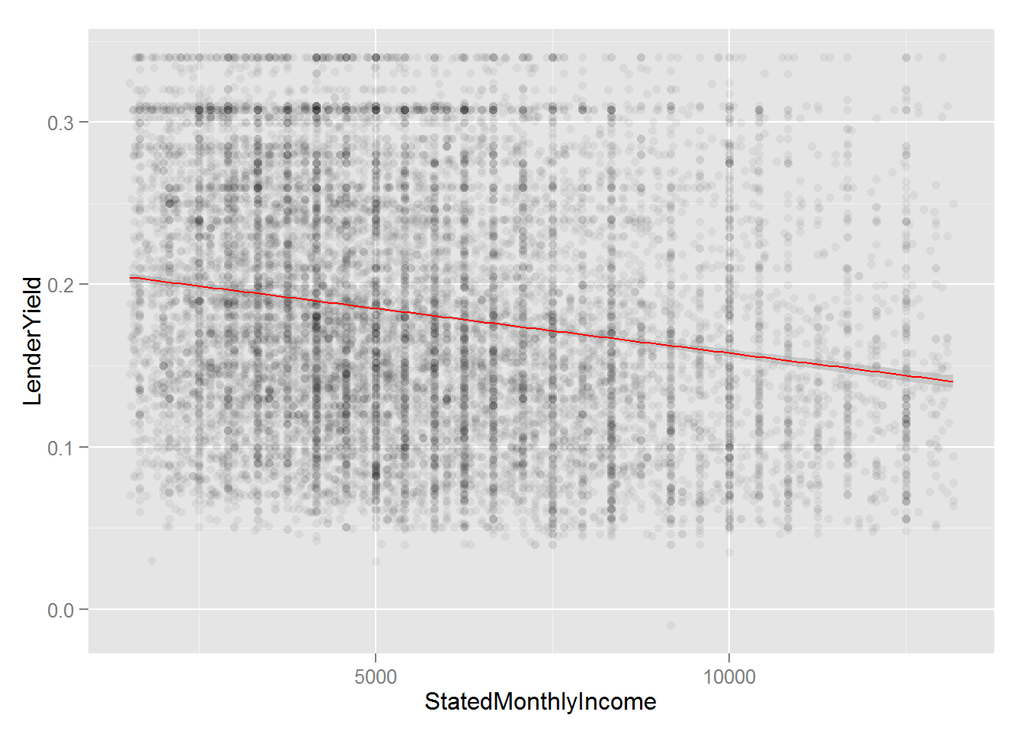

```
##
##  Pearson's product-moment correlation
##
## data:  pldca$StatedMonthlyIncome and pldca$LenderYield
## t = -13.107, df = 14715, p-value < 2.2e-16
## alternative hypothesis: true correlation is not equal to 0
## 95 percent confidence interval:
##  -0.1233663 -0.0914263
## sample estimates:
##       cor
## -0.107424
```

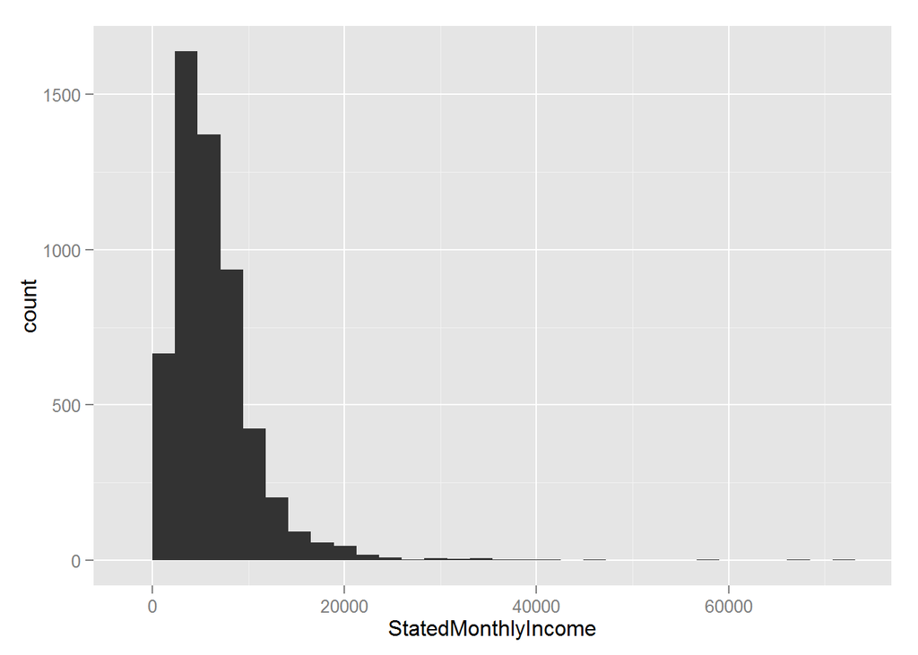

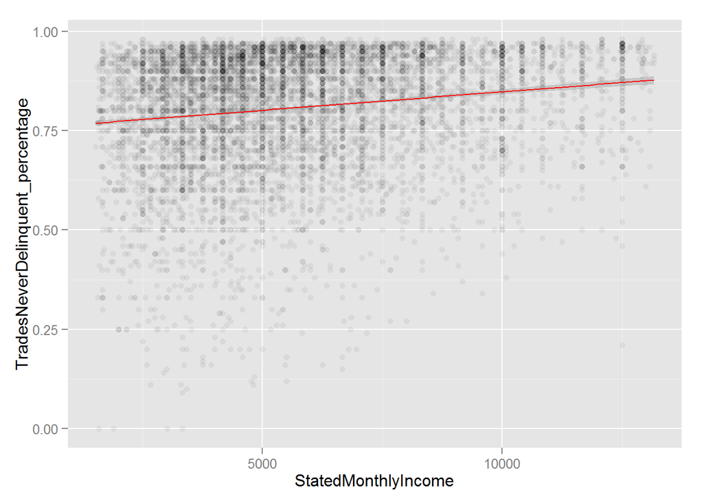

```
##
##  Pearson's product-moment correlation
##
## data:  pldca$StatedMonthlyIncome and pldca$TradesNeverDelinquent_percentage
## t = 7.2586, df = 14015, p-value = 4.117e-13
## alternative hypothesis: true correlation is not equal to 0
## 95 percent confidence interval:
##  0.04468907 0.07767496
## sample estimates:
##        cor
## 0.06119873
```

2 Plots have been plotted to understand the relation between the Stated Monthly Income and Trades Never Delinquent Percentage

The first plot is a bar plot of Stated Monthly Income for Trades which have never been Delinquent. Most of the cases are for Monthly Income less than 10000 which is intuitive as most of the Loan cases also have Monthly Income less than 10000

The Second Plot is a scatter plot between Stated Monthly Income and Trades Never Delinquent Percentage for cases having Delinquent Trades

The correlation coefficient is 0.061 which suggests that the correlation is not meaningful. The regression line is gradually increasing. The TradesNeverDelinquent_percentage is more dispersed for the lower income group with the 2 extremes being wider than for the higher income group where the 2 extremes are narrower. Though there is no strong correlation it seems that the Delinquency is less for the higher income group

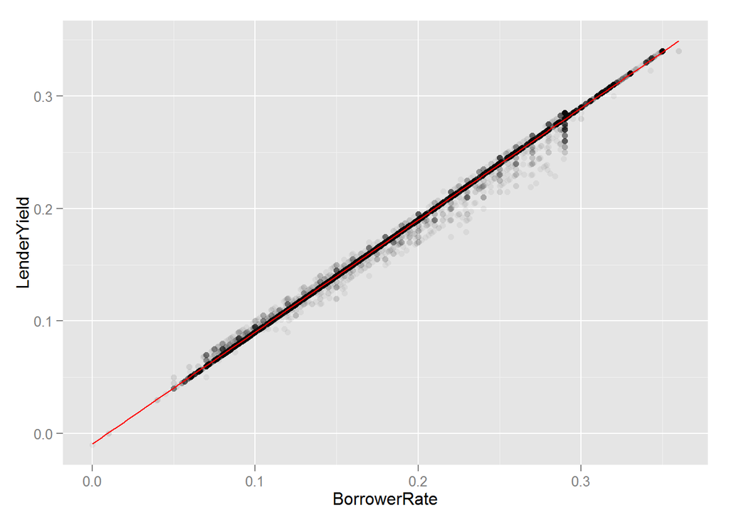

```
##
##  Pearson's product-moment correlation
##
## data:  pldca$BorrowerRate and pldca$LenderYield
## t = 2963.415, df = 14715, p-value < 2.2e-16
## alternative hypothesis: true correlation is not equal to 0
## 95 percent confidence interval:
##  0.9991358 0.9991898
## sample estimates:
##       cor
## 0.9991632
```

The correlation coefficient is 0.999 which suggests that the correlation is very Strong. The Lender Yield increases with increase in Borrower Rate

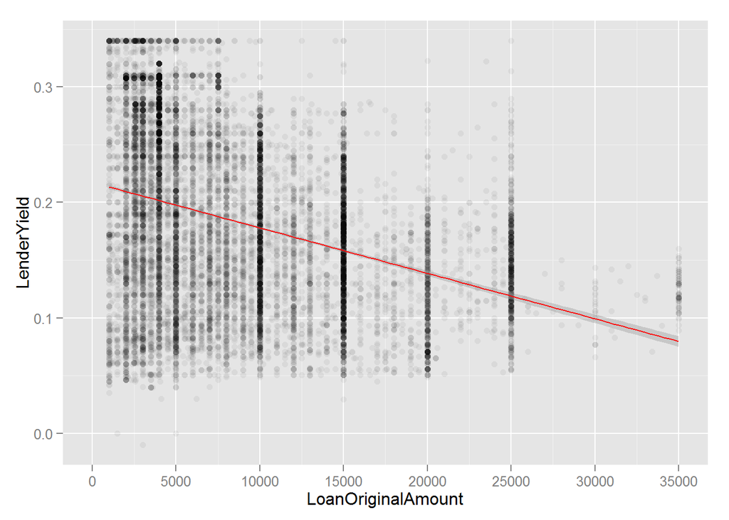

```
##
##  Pearson's product-moment correlation
##
## data:  pldca$LoanOriginalAmount and pldca$LenderYield
## t = -44.8053, df = 14715, p-value < 2.2e-16
## alternative hypothesis: true correlation is not equal to 0
## 95 percent confidence interval:
##  -0.3606179 -0.3321833
## sample estimates:
##        cor
## -0.3464802
```

The correlation coefficient is -0.346 which suggests that the correlation is weak. The LenderYield decreases when the LoanOriginalAmount increases.

# Bivariate Analysis

### Talk about some of the relationships you observed in this part of the investigation. How did the feature(s) of interest vary with other features in the dataset?

The first 3 quantiles of Lender Yield and Borrower Rate for Credit grade AA is less than 10%. The median is gradually increasing from Credit Grade AA to HR. We also see that for HR the first quantile itself is just below the 30% mark. The median and third quantile are almost at the same level above 30% mark for HR

The Charged off cases and the Defaulted cases are increasing from AA to HR. The past due cases are also more for the lower credit grades as compared to the higher credit grades

For the Owned Home category, there are more number of cases for the higher Credit Grades (AA, A, B and C) for as compared to the lower Credit Grades (D, E and HR) whereas, for the Rented Home category it is gradually increasing from AA to C and then gradually decreases from C to HR. Except for the Credit Grade AA and A there are more number of cases for Rented Home category as compared to Owned home category

Trades are more delinquent for Rented Home Borrowers as compared to the Own Home Borrowers

The Rented home borrowers have a better Debt to Income ratio than Own Home Borrowers

The Occupations “Aviation” and “Car Dealer” have more Trade Delinquencies as compared to other Trades with their mean around 25%. For these 2 groups the number of Trades never Delinquent is also very low. Followed by these 2 groups are the groups “Home Maker”, “Religious” and “Realtor” which have higher Delinquency with mean around 20% and these groups also have very low number of Trades which were never Delinquent.

The Occupations “Other”, “Clerical”, “Computer”, “Professional” and “Sales” have more number of non Delinquent Trades as compared to other Occupations

The correlation coefficient of Stated Monthly Income to Loan Amount is 0.208 which suggests that the correlation is not meaningful. But, we see that the regression line is gradually increasing which is due to variation in the upper side of the Loan amount. The Loan amount for lower income group is more concentrated on the lower side of the regression line whereas for higher Income group the data is more dispersed and evenly distributed above and below the regression line. This might be because higher income group might be having Loan eligibility for higher amount whereas the eligibility for lower income group it might be less and the higher income group inspite being eligible for higher loan amounts many are applying for much less amount than their eligibility. Also, we see that certain loan amounts are more popular. The Loan amounts of 4000 and 5000 is more popular among low income groups. The loan amount of 10000 is popular among people having income above 2500. The loan amount of 15000 is popular among people having income above 4000. The loan amounts of 15000, 20000 and 25000 are more popular than other amounts among people having income above 10000

The correlation coefficient of Stated Monthly Income to Debt to Income Ratio is - 0.127 which suggests that the correlation is not meaningful. The average Debt to Income Ratio is high for lower income group and gradually decreases for higher income group

The correlation coefficient of Debt To Income Ratio and Loan amount is 0.027 which suggests that the correlation is not meaningful. The average Debt To Income Ratio across all Loan amounts is almost same at around 0.25.

The correlation coefficient of Debt to Income ratio and Lender Yield is 0.054 which suggests that the correlation is not meaningful. The average Debt to Income ratio for lower Lender Yield is low and is gradually increasing for higher Lender Yield

The correlation coefficient of Trades Never Delinquent percentage and Debt to Income Ratio is 0.050 which suggests that the correlation is not meaningful. The average Debt to Income Ratio is low for lower Trades Never Delinquent Percentage and is gradually increasing for higher Trades Never Delinquent Percentage. The Debt to Income Ratio is more dispersed for higher values of Trades Never Delinquent percentage and the 2 extremes are more wider for its higher values and is narrower for its lower values. There are more data points for higher values of Trades Never Delinquent percentage as compared to the lower values

The correlation coefficient of Stated Monthly Income and Trades Never Delinquent percentage is 0.061 which suggests that the correlation is not meaningful. The average Trades Never Delinquent percentage is low for lower income group and gradually increases for higher income group

The correlation coefficient of Borrower Rate and Lender Yield is 0.999 which suggests that the correlation is very Strong. The Lender Yield increases proportionally with increase in Borrower Rate

The correlation coefficient of Loan Amount and Lender Yield is -0.346 which suggests that the correlation is weak. The average Lender Yield decreases when the Loan Amount increases.

### Did you observe any interesting relationships between the other features (not the main feature(s) of interest)?

The Loan amounts of 4000 and 5000 is more popular among low income groups. The loan amount of 10000 is popular among people having income above 2500. The loan amount of 15000 is popular among people having income above 4000. The loan amounts of 15000, 20000 and 25000 are more popular than other amounts among people having income above 10000

### What was the strongest relationship you found?

The Lender Yield and Borrower Rate are very strongly correlated and the correlation is positive. The correlation coefficient being 0.999

This is as expected because if the Borrower is borrowing at a higher rate then the Yield will be higher.

# Multivariate Plots Section

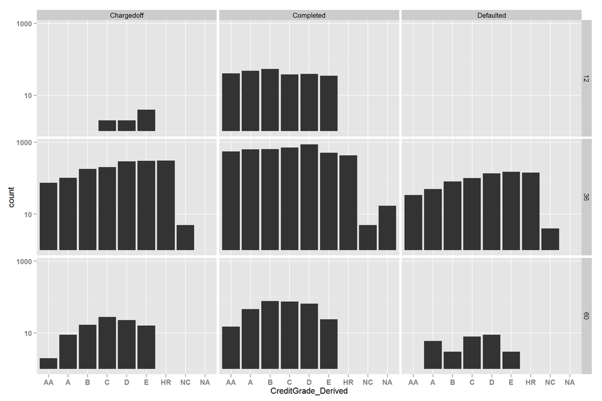

We are considering only the Closed Loans for this analysis.

We have log transformed the Yaxis

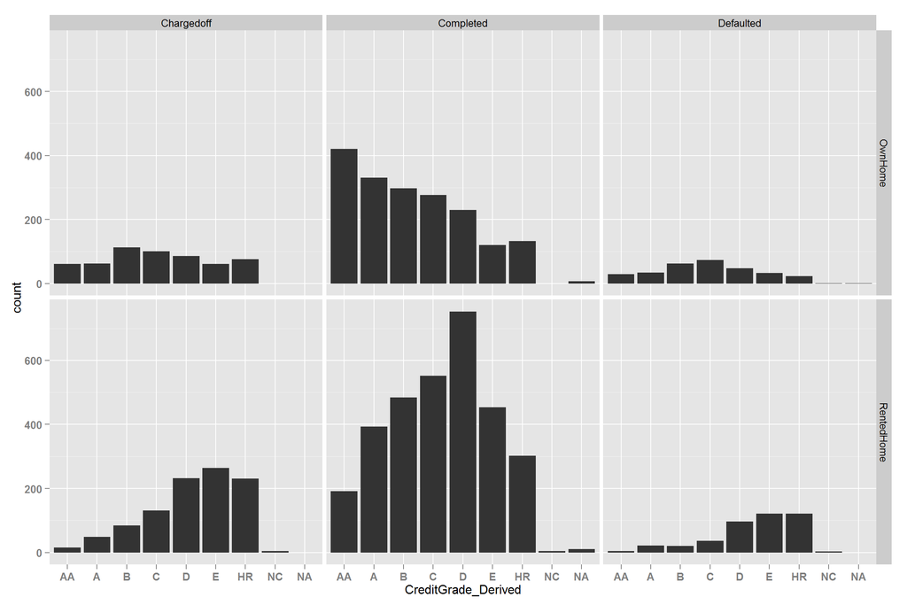

We are considering only the Closed Loans for this analysis.  
We see that the charged off and defaulted cases for Own Home borrowers is more as compared to the Rented Home borrowers for higher Credit ratings. For lower credit ratings the charged off and defaulted cases are more for Rented Home borrowers as compared to Own Home borrowers. For the Own Home borrowers the completed Loan cases are high for higher credit ratings and gradually decreases for lower credit ratings. For Rented Home borrowers the number of completed Loan cases have an approximate normal distribution with higher ratings having lower number of cases and gradually increasing and peaking for credit rating of ‘D’ and then again decreasing for lower credit ratings

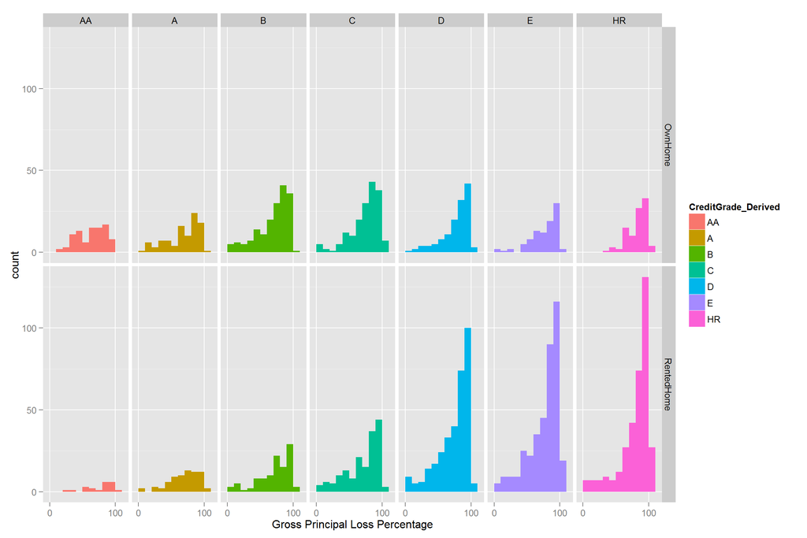

We are considering only cases where the Principal Loss Percentage > 0 for this analysis. For Own Home borrowers we see that Principal Loss percentage is almost uniform across all Credit ratings. Credit grade B has more cases than the other cases followed by C then D then A then HR then AA and then E. For Rented Home borrowers we see that Principal Loss percentage gradually increases from higher ratings to Lower ratings with D and E having almost same number of cases. Comparing the Own Home borrowers to Rented Home borrowers we see that for higher credit ratings of AA, A and B Own Home borrowers have more cases as compared to the Rented Home borrowers. For Credit rating C both Own Home and Rented Home borrowers have almost same number of cases. For lower credit ratings of D, E and HR Rented Home borrowers far exceeds in number as compared to Own Home borrowers. We also see that there are many cases for Rented Home borrowers with credit rating D, E and HR where the Loss Percentage is almost 100%

```
##    Min. 1st Qu.  Median    Mean 3rd Qu.    Max.
##    3379    5253    9757    8640   11120   13690
```

```
##    Min. 1st Qu.  Median    Mean 3rd Qu.    Max.
## 0.07488 0.11660 0.18280 0.18730 0.26180 0.30400
```

```
##    Min. 1st Qu.  Median    Mean 3rd Qu.    Max.
##  0.7801  0.8543  0.8812  0.8855  0.9279  0.9666
```

```
##    Min. 1st Qu.  Median    Mean 3rd Qu.    Max.
##   3.965   5.747  10.990  12.390  15.990  31.880
```

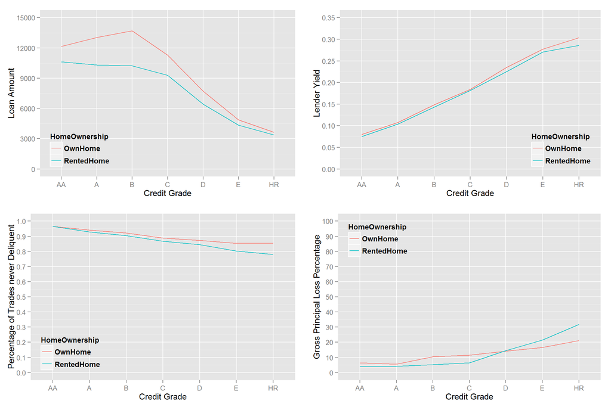

We have ignored the Credit Grades ‘NA’ and ‘NC’ from our plot

The plot of Loan amount and Credit Grade shows that across all credit grades the Owned Home borrowers have a slightly higher Loan amount as compared to the Rented Home borrowers. For Grades A, B and C this difference is higher than the other Credit grades. The loan amount for higher Credit gradess is higher and decreases for lower Credit grades. There is a gradual decrease from B to HR

The plot of Lender Yield and Credit Grade shows that across all credit grades the Owned Home borrowers and the Rented Home borrowers have similar Lender Yield The Owned Home line is slightly above the Rented Home line which shows that Lender Yield is slightly better for Owned Home borrowers as compared to Rented Home borrowers. The Lender Yield is gradually increasing from AA to HR with AA having the least Lender Yield and HR having the most Lender Yield

The plot of Trades never Delinquent and Credit Grade shows that for higher credit grades (AA and A) both Owned Home borrowers and Rented Home borrowers have almost same Delinquency Percentage. For lower credit grades (B to HR) the difference widens with Owned Home borrowers having a slightly lower delinquency as compared to the Rented Home borrowers. The Trade delinquency increases as the credit grade decreases from AA to HR

The plot of Gross Principal Loss Percentage and Credit Grade shows that for higher credit grades (AA, A, B and C) Rented Home borrowers have lower Principal Loss percentage as compared to Owned Home borrowers. The 2 lines cross each other at D. For lower credit grades (E and HR) Owned Home borrowers have lower Principal Loss Percentage as compared to Rented Home borrowers. The Gross Principal Loss Percentage increases from higher credit grade to lower credit grade fram AA to HR.

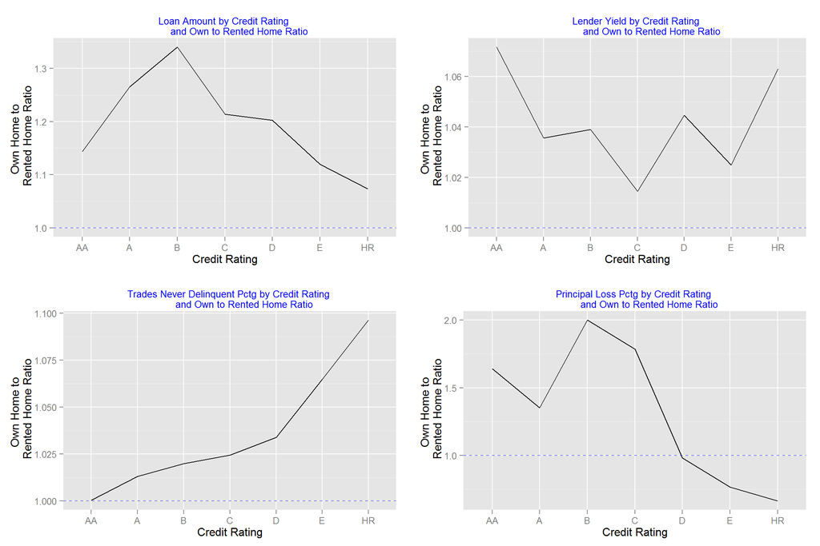

The plot of Loan amount and Credit Rating shows that across all credit ratings the Owned Home to Rented Home borrowers ratio is greater than 1. This means that Owned Home borrowers are receiving higher Loan amount than the Rented Home borrowers across all credit ratings. The ratio gradually increases from Credit rating AA to Credit rating B and then decreases from B to HR

The plot of Lender Yield and Credit Rating shows that across all credit grades the Owned Home to Rented Home borrowers ratio is greater than 1. This means that the Lender Yield is slightly more for Owned Home borrowers than the Rented Home borrowers. The ratio has a zig zag path which decreases from AA to A then increases slightly from A to B then again decreases from B TO C then again increases from C to D then again decreases from D to E and increases from E to HR

The plot of Trades never Delinquent Percentage and Credit Rating shows that for Credit Rating AA the ratio for Owned Home to Rented Home borrower ratio is 1 which means Trades never Delinquent percentage is almost same for Credit Rating AA. The ratio increases gradually from Credit Rating AA to HR. The Trades never Delinquent percentage is slightly better for Owned Home borrowers as compared to Rented Home borrowers for Credit Rating A to HR

The plot of Principal Loss Percentage and Credit Rating shows that for higher credit grades (AA, A, B and C) Owned Home borrowers have higher Principal Loss percentage as compared to Rented Home borrowers. For the Credit Rating ‘D’ the Principal Loss Percentage is almost same for Owned Home borrowers and Rented Home borrowers. For lower credit grades (E and HR) the Owned Home borrowers have lower Principal Loss Percentage as compared to Rented Home borrowers

# Multivariate Analysis

### Talk about some of the relationships you observed in this part of the investigation. Were there features that strengthened each other in terms of looking at your feature(s) of interest?

The charged off and defaulted cases for Own Home borrowers is more as compared to the Rented Home borrowers for higher Credit ratings. For lower credit ratings the charged off and defaulted cases are more for Rented Home borrowers as compared to Own Home borrowers. For the Own Home borrowers the completed Loan cases are high for higher credit ratings and gradually decreases for lower credit ratings. For Rented Home borrowers the number of completed Loan cases have an approximate normal distribution with higher ratings having lower number of cases and gradually increasing and peaking for credit rating of ‘D’ and then again decreasing for lower credit ratings

For Own Home borrowers we see that number of cases with Principal Loss percentage is almost uniform across all Credit ratings. For Rented Home borrowers we see that number of cases with Principal Loss percentage gradually increases from higher ratings to Lower ratings

The Owned Home borrowers are receiving higher Loan amount than the Rented Home borrowers across all credit ratings. The loan amount for higher Credit grades is higher and decreases for lower Credit grades

The Lender Yield is slightly higher for Owned Home borrowers than the Rented Home borrowers. The Lender Yield is gradually increasing from higher to lower credit grades

The Trade delinquency increases as the credit grade decreases for both Owned and Rented Home borrowers. The Trade Delinquency is slightly lesser for Owned Home borrowers as compared to Rented Home borrowers for all Credit Grades except AA for which the Trade Delinquency is almost the same for both groups

The Principal Loss is gradually increasing from Higher to Lower Credit Grades for both Owned and Rented Home borrowers. For higher credit grades (AA, A, B and C) Owned Home borrowers have higher Principal Loss as compared to Rented Home borrowers. For the Credit Rating ‘D’ the Principal Loss is almost same for Owned and Rented Home borrowers. For lower credit grades (E and HR) the Owned Home borrowers have lower Principal Loss Percentage as compared to Rented Home borrowers

### Were there any interesting or surprising interactions between features?

As expected the Loan Amount is high for higher Credit Grades and low for lower Credit Grades. We also see that Owned Home borrowers are borrowing slightly higher amounts as compared to the Rented Home borrowers

The Lender Yield is low for higher Credit Grades and high for lower Credit Grades. This shows that there is a risk reward tradeoff while granting the loan. The riskier investment (lower Credit Grades) is fetching higher Lender Yield and the safer investment (higher Credit Grades) is fetching lower Lender Yield

The charged off and defaulted cases for Own Home borrowers is more as compared to the Rented Home borrowers for higher Credit ratings. For lower credit ratings the charged off and defaulted cases are more for Rented Home borrowers as compared to Own Home borrowers

### OPTIONAL: Did you create any models with your dataset? Discuss the strengths and limitations of your model.

# Final Plots and Summary

### Plot One

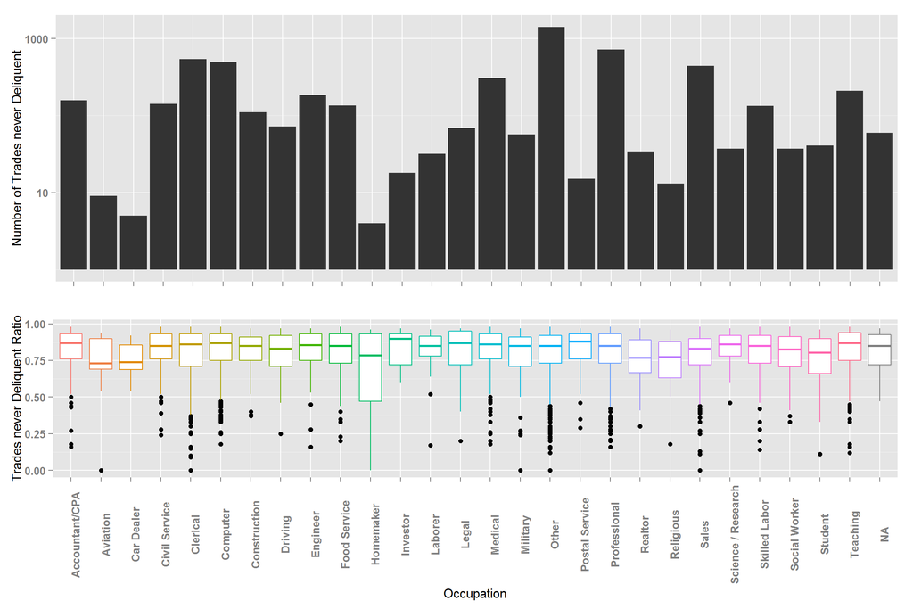

### Description One

We are analyzing the Trade Deliquencies across different Occupations in this plot

We have log transformed the Y axis for the bar chart of Occupation for Trades Never Delinquent Percentage equal to 1 as there is a wide difference between the maximum and minimum Values

The Occupations “Aviation” and “Car Dealer” have more Trade Delinquencies as compared to other Trades with their mean around 25% (The mean of trades not Delinquent is around 75% for these 2 groups implying 25% Delinquency). For these 2 groups the number of Trades never Delinquent is also very low. Followed by these 2 groups are the groups “Home Maker”, “Religious” and “Realtor” which have higher Delinquency with mean around 20% and these groups also have very low number of Trades which were never Delinquent.

The Occupations “Other”, “Clerical”, “Computer”, “Professional” and “Sales” have more number of non Delinquent Trades as compared to other Occupations

### Plot Two

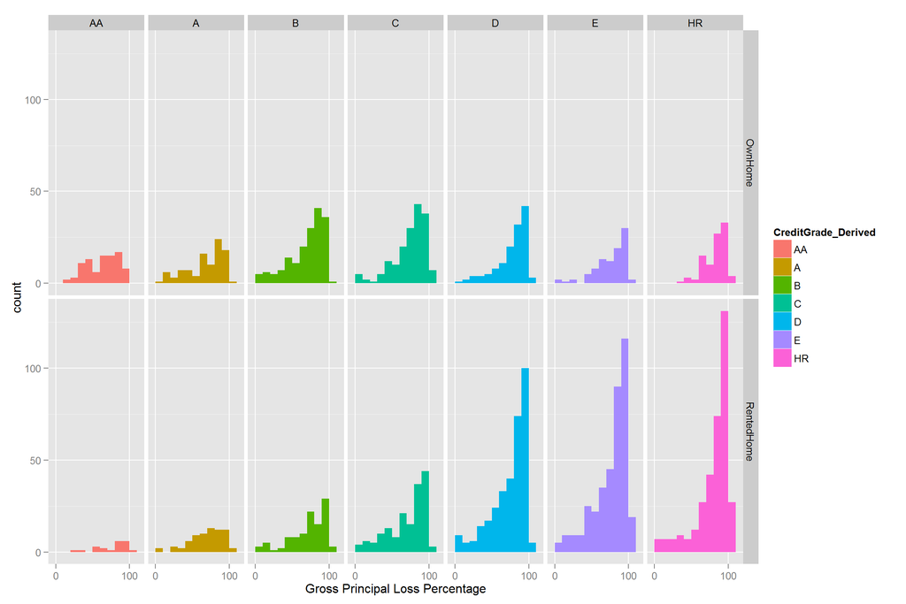

### Description Two

We are analyzing the Gross Principal Loss Percentage for different Credit Grades and Owned and Rented Home Categories

For Own Home borrowers we see that Principal Loss percentage is almost uniform across all Credit ratings. Credit grade B has more cases than the other cases followed by C then D then A then HR then AA and then E. For Rented Home borrowers we see that Principal Loss percentage gradually increases from higher ratings to Lower ratings with D and E having almost same number of cases. Comparing the Own Home borrowers to Rented Home borrowers we see that for higher credit ratings of AA, A and B Own Home borrowers have more cases as compared to the Rented Home borrowers. For Credit rating C both Own Home and Rented Home borrowers have almost same number of cases. For lower credit ratings of D, E and HR Rented Home borrowers far exceeds in number as compared to Own Home borrowers. We also see that there are many cases for Rented Home borrowers with credit rating D, E and HR where the Loss Percentage is almost 100%

### Plot Three

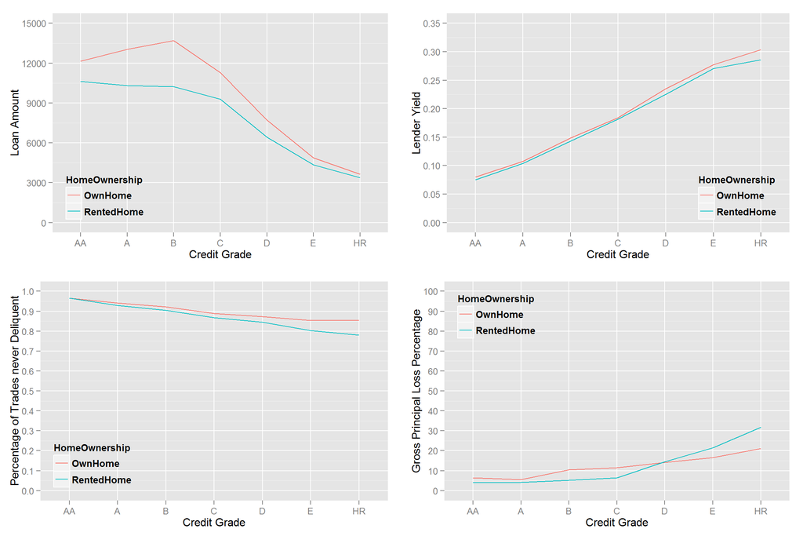

### Description Three

We are comparing the Loan Amount, Lender Yield, Trade Delinquencies and Principal Loss percentage between Owned and Rented Home borrowers for different Credit Grades

The plot of Loan amount and Credit Grade shows that across all credit grades the Owned Home borrowers have a slightly higher Loan amount as compared to the Rented Home borrowers. For Grades A, B and C this difference is higher than the other Credit grades. The loan amount for higher Credit gradess is higher and decreases for lower Credit grades. There is a gradual decrease from B to HR

The plot of Lender Yield and Credit Grade shows that across all credit grades the Owned Home borrowers and the Rented Home borrowers have similar Lender Yield The Owned Home line is slightly above the Rented Home line which shows that Lender Yield is slightly better for Owned Home borrowers as compared to Rented Home borrowers. The Lender Yield is gradually increasing from AA to HR with AA having the least Lender Yield and HR having the most Lender Yield.

The plot of Trades never Delinquent and Credit Grade shows that for higher credit grades (AA and A) both Owned Home borrowers and Rented Home borrowers have almost same Delinquency Percentage. For lower credit grades (B to HR) the difference widens with Owned Home borrowers having a slightly lower delinquency as compared to the Rented Home borrowers. The Trade delinquency increases as the credit grade decreases from AA to HR

The plot of Gross Principal Loss Percentage and Credit Grade shows that for higher credit grades (AA, A, B and C) Rented Home borrowers have lower Principal Loss percentage as compared to Owned Home borrowers. The 2 lines cross each other at D. For lower credit grades (E and HR) Owned Home borrowers have lower Principal Loss Percentage as compared to Rented Home borrowers. The Gross Principal Loss Percentage increases from higher credit grade to lower credit grade fram AA to HR

# Reflection

The Prosper Loan data set contains information on 113937 loan records. I focussed on the State of California for doing the Exploratory analysis as it has 14717 records (almost 1/10th of the total loan records). I started by going through the Prosper website to understand the concept and details of some of the fields in the data set. Then I started understanding the individual variables in the data set, and then I explored interesting questions and leads as I continued to make observations on plots

Following are some of the interesting features which I observed during the exploratory analysis

There are certain occupations which have more Trade Delinquencies as compared to others. The Occupations “Aviation” and “Car Dealer” have more Trade Delinquencies as compared to other Trades with their mean around 25%. Followed by these 2 groups are the groups “Home Maker”, “Religious” and “Realtor” which have higher Delinquency with mean around 20%. All these groups also have very low number of Trades which were never Delinquent. The Occupations “Other”, “Clerical”, “Computer”, “Professional” and “Sales” have more number of non Delinquent Trades as compared to other Occupations

There are 3 loan terms 12, 36 and 60 months. The most popular loan term is 36 months

There are about 33% more Rented Home borrowers as compared to Owned Home borrowers in the data set

The Borrower rate of Interest and Lender Yield is low for higher Credit Grades and high for lower Credit Grades. The median gradually increases from higher Credit Grade (AA) to lower Credit Grade (HR)

The Owned Home borrowers seem to be receiving higher Loan amount than the Rented Home borrowers across all credit ratings. The loan amount for higher Credit grades is higher and decreases for lower Credit grades

The Lender Yield seems to be slightly higher for Owned Home borrowers than the Rented Home borrowers. The Lender Yield is gradually increasing from higher to lower credit grades

The Trade delinquency increases as the credit grade decreases for both Owned and Rented Home borrowers. The Trade Delinquency is slightly lesser for Owned Home borrowers as compared to Rented Home borrowers for all Credit Grades except AA for which the Trade Delinquency is almost the same for both groups

The Principal Loss is gradually increasing from Higher to Lower Credit Grades for both Owned and Rented Home borrowers. For higher credit grades (AA, A, B and C) Owned Home borrowers have higher Principal Loss as compared to Rented Home borrowers. For the Credit Rating ‘D’ the Principal Loss is almost same for Owned and Rented Home borrowers. For lower credit grades (E and HR) the Owned Home borrowers have lower Principal Loss Percentage as compared to Rented Home borrowers

There are a few records (5-10 % records) which does not have values for Principal Loss and Trade delinquency and hence have not got considered in our plot. This might not be having an impact on our analysis assuming these records also will have similar values as the rest (90-95 %) of the loan records